# WK04-HW_GII2010vs2019

2025-10-23

## Homework WK 04

The purpose is to create a map that show cases the difference in Gender inequality between the year 2010 and 2019 in the world.

### **Refferences:**

#### Gender Inequality Index Data

**File:** HDR_Composite_indices_complete_time_series.csv

**URL:**[Human Development Reports](https://hdr.undp.org/data-center/documentation-and-downloads).

#### Spatial Data of the World

**File:** GeoJSON file

**URL:** [ArcGIS](https://hub.arcgis.com/datasets/2b93b06dc0dc4e809d3c8db5cb96ba69_0/explore?location=-0.146900%2C0.000000%2C1.41)

### **Mythology:**

  create a new column that calculates the difference between 2010 and 2019 named gii_diff

```r
library(sf)
library(here)
library(janitor)
library(tidyverse)
library(countrycode)
library(tmap)
```

```r
csv <- read_csv(here::here("DATA","HDR25_Composite_indices_complete_time_series.csv"),
                          locale = locale(encoding = "latin1"),
                          na = " ", skip=0)
world <- st_read(here::here("DATA","World_Countries_(Generalized)_9029012925078512962.geojson"))
slice_head(csv, n = 5)
```

```
## # A tibble: 5 × 1,112
##   iso3  country hdicode region hdi_rank_2023 hdi_1990 hdi_1991 hdi_1992 hdi_1993
##   <chr> <chr>   <chr>   <chr>          <dbl>    <dbl>    <dbl>    <dbl>    <dbl>
## 1 AFG   Afghan… Low     "SA"             181    0.285    0.291    0.301    0.311
## 2 ALB   Albania Very H… "ECA"             71    0.654    0.638    0.622    0.624
## 3 DZA   Algeria High    "AS"              96    0.595    0.596    0.601    0.603
## 4 AND   Andorra Very H… ""                32   NA       NA       NA       NA
## 5 AGO   Angola  Medium  "SSA"            148   NA       NA       NA       NA
## # ℹ 1,103 more variables: hdi_1994 <dbl>, hdi_1995 <dbl>, hdi_1996 <dbl>,
## #   hdi_1997 <dbl>, hdi_1998 <dbl>, hdi_1999 <dbl>, hdi_2000 <dbl>,
## #   hdi_2001 <dbl>, hdi_2002 <dbl>, hdi_2003 <dbl>, hdi_2004 <dbl>,
## #   hdi_2005 <dbl>, hdi_2006 <dbl>, hdi_2007 <dbl>, hdi_2008 <dbl>,
## #   hdi_2009 <dbl>, hdi_2010 <dbl>, hdi_2011 <dbl>, hdi_2012 <dbl>,
## #   hdi_2013 <dbl>, hdi_2014 <dbl>, hdi_2015 <dbl>, hdi_2016 <dbl>,
## #   hdi_2017 <dbl>, hdi_2018 <dbl>, hdi_2019 <dbl>, hdi_2020 <dbl>, …
```

```r
slice_head(world, n = 5)
```

```
## Simple feature collection with 5 features and 5 fields
## Geometry type: MULTIPOLYGON
## Dimension:     XY
## Bounding box:  xmin: -170.8232 ymin: -14.37555 xmax: 74.91574 ymax: 42.66035
## Geodetic CRS:  WGS 84
##   FID        COUNTRY ISO    COUNTRYAFF AFF_ISO                       geometry
## 1   1    Afghanistan  AF   Afghanistan      AF MULTIPOLYGON (((61.27655 35...
## 2   2        Albania  AL       Albania      AL MULTIPOLYGON (((19.57083 41...
## 3   3        Algeria  DZ       Algeria      DZ MULTIPOLYGON (((4.603354 36...
## 4   4 American Samoa  AS United States      US MULTIPOLYGON (((-170.7439 -...
## 5   5        Andorra  AD       Andorra      AD MULTIPOLYGON (((1.445836 42...
```

We need to merge according to country, but first lets clean the lists, or merge via the iso

```r
csv <- csv %>% clean_names()
world <- world %>% clean_names()
```

edit the csv do it will only contain the column we need

```r
csvedited <- csv %>%
  dplyr::select(iso3,
                country,
                gii_2010,
                gii_2019) %>%
  mutate(gii_diff = (gii_2019 - gii_2010)) %>%
  na.omit()
```

Join the csv with the world map

```r
mergedmap <- world %>%
  left_join(csvedited, by = c("country" = "country"))
```

Clean again, i wonder if i can make it all together

```r
mergedmap <- mergedmap %>%
  dplyr::select(country,
                iso3,
                gii_2010,
                gii_2019,
                gii_diff,
                geometry)
```

lets create a map

```r
tmap_mode("plot")
```

```
## ℹ tmap modes "plot" - "view"
## ℹ toggle with `tmap::ttm()`
```

```r
qtm(mergedmap, fill = "gii_diff")
```

```
## [tip] Consider a suitable map projection, e.g. by adding `+ tm_crs("auto")`.
## [scale] tm_polygons:() the data variable assigned to 'fill' contains positive and negative values, so midpoint is set to 0. Set 'midpoint = NA' in 'fill.scale = tm_scale_intervals(<HERE>)' to use all visual values (e.g. colors)
##
## [scale] tm_symbols:() the data variable assigned to 'fill' contains positive and negative values, so midpoint is set to 0. Set 'midpoint = NA' in 'fill.scale = tm_scale_intervals(<HERE>)' to use all visual values (e.g. colors)
##
```

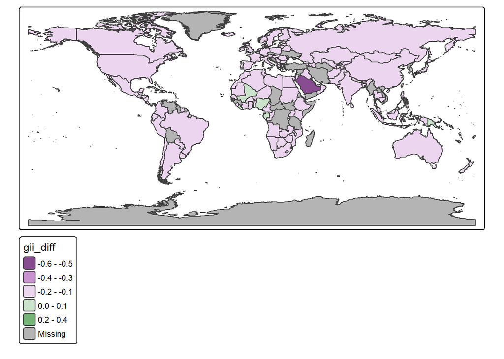

lets have fun

```r
tmap_mode("plot")
```

```
## ℹ tmap modes "plot" - "view"
```

```r
qtm(mergedmap,
    fill = "gii_diff",
    fill.palette = c("red", "blue"),
    title = "Countries who improved their gender equality through the years.")
```

[output not shown]

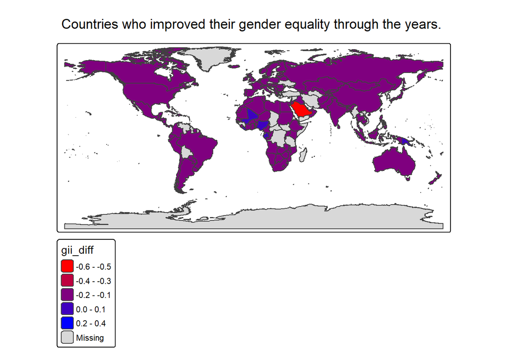

with gimini

```r
tmap_mode("plot")
```

```
## ℹ tmap modes "plot" - "view"
```

```r
qtm(mergedmap,
    fill = "gii_diff",
    # 1. Use a diverging color scheme
    # 'RdBu' is Red-Blue, 'BrBG' is Brown-Green, both good for divergence
    fill.palette = "RdBu",
    # 2. Set the midpoint of the color scale to 0 (no change)
    fill.midpoint = 0,
    # 3. Adjust the legend title to be clearer
    title = "Change in Gender Inequality Index (2019 minus 2010)",
    # 4. Add a legend text label to explain the difference
    title.col = "GII Difference") +
tm_layout(
    # 6. Center the main title
    main.title.position = "center",
    main.title.size = 1.2
)
```

[output not shown]

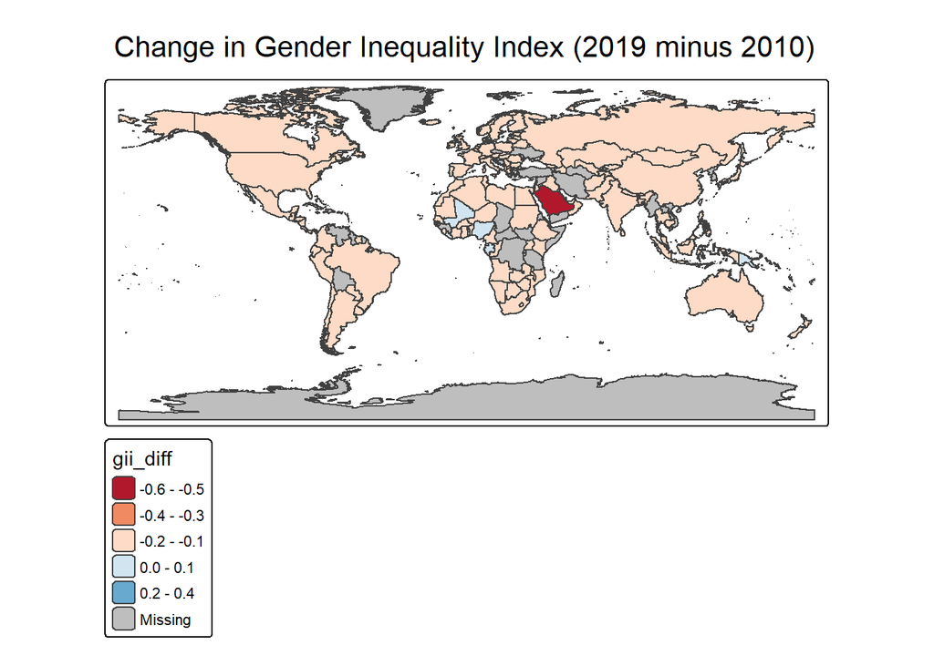